# Name: Tanner Woods

# Question 1

**(See below)**

# Question 2

A)

I subsetted the following variables: **[HalfBath, FullBath, BsmtFullBath, GarageCars, ExterQual, KitchenQual, CentralAir, and PavedDrive]**.

For the quantitative variables **HalfBath**, **FullBath**, **BsmtFullBath**, and **GarageCars**, my rationale is as follows:

> **HalfBath**, **FullBath**, and **BsmtFullBath** show positive correlation in the constructed heatmap below, and can effectively account for mist other measures of room quantitiy and living space (e.g. TotRmsAbvGrd, GrLivingSpace, etc.).

> **GarageCars** shows positive correlation, while also effectively accounting for GarageArea. Generally, the more cars a garage can hold the large it will tend to be.

For the categorical variables:

> **ExterQual** and **KitchenQual** helps break up the more comprehensive OverallQual, while helping to narrow our focus on the effect of two critical factors for a property's sale price. I believe the quality of the exterior trumps the actual material, while the quality of the kitchen - which can be a centerpiece of the property - better accounts for the weight of the kitchen on price (as most properties listed only have 1 kitchen).

> **CentralAir** is a crucial factor for property price, since weather in Ames, Iowa can reach below freezing. Not having the capacity for central heating could crater the asking price of a property due to the cost of future installation.

> **PavedDrive** allows us to account for potentially unfinished or in-progress properties, while also accounting for the negative effect of an unpaved (e.g. Dirt, gravel, etc.) road on a property's price.

B)

**(See below)**

C)

**(See below)**

# Question 3

A)

B)

I believe some form of transformation would be appropriate for **SalePrice**. If we can adjust it to a more normal distribution, then we can more easily fulfill an assumption of normality when performing confidence intervals and tests of significance. If we choose not to adjust **SalePrice**, then we might risk constructing statistical instruments that provide misleading interpretations.

C)

A Box-Cox transformation provided a $\lambda$ of $\approx$ -0.0769.

**(See below for plots)**

# Question 4

A)

**Quantitative coefficients:**

> **HalfBath**: A marginal 1-unit change = $\Delta$ 10.35% in SalePrice

> **FullBath**: A marginal 1-unit change = $\Delta$ 19.92% in SalePrice

> **BsmtFullBath**: A marginal 1-unit change = $\Delta$ 11.34% in SalePrice

> **GarageCars**: A marginal 1-unit change = $\Delta$ 14.48% in SalePrice

**Categorical exterior quality coefficients:**

> **ExterQual_Fa**: $\Delta$ -44.07% in SalePrice compared to an excellent (Ex) exterior quality

> **ExterQual_Gd**: $\Delta$ -16.57% in SalePrice compared to an excellent (Ex) exterior quality

> **ExterQual_TA**: $\Delta$ -28.51% in SalePrice compared to an excellent (Ex) exterior quality

**Categorial kitchen quality coefficients:**

> **KitchenQual_Fa**: $\Delta$ -29.87% in SalePrice compared to an excellent (Ex) kitchen quality

> **KitchenQual_Gd**: $\Delta$ -20.70% in SalePrice compared to an excellent (Ex) kitchen quality

> **KitchenQual_TA**: $\Delta$ -30.26% in SalePrice compared to an excellent (Ex) kitchen quality

**Categorical paved drive coefficients:**

> **PavedDrive_P**: $\Delta$ 10.97% in SalePrice compared to no (N) paved drive

> **PavedDrive_Y**: $\Delta$ 8.57% in SalePrice compared to no (N) paved drive

**Categorical central air coefficients:**

> **CentralAir_Y**: $\Delta$ 22.03% in SalePrice compared to no (N) central heating

$R^{2}:$

> The constructed model accounts for 73.80% of the variance seen within the data.

**Tests of significance:**

As the p-value for all regression coefficients < $\alpha$ = 0.05, we can - with 95% confidence - reject {$H_{0}$: $\beta_{0,1,...,13}$ = 0} in favor of our constructed coefficients.

B)

For my interactions effects, I included the relationship between the like-like dummy variables of **KitchenQual** and **ExterQual** to represent the positive correlation between a similar kitchen quality and external quality.

C)

Due to the Jarque-Bera test providing a large test statistic and a p $\approx$ 0 < $\alpha$ $\approx$ 0.01 (given the sample size of 1460), we can reject {$H_{0}$: The residuals of the MR on log(**SalePrice**) are normally distributed} in favor of {$H_{1}$: The residuals of the MR on log(**SalePrice**) are not normally distributed}.

# Question 1 (Code)

```python
import numpy as np
import pandas as pd
import matplotlib.pyplot as plt
import seaborn as sns
import scipy as sp
from scipy import stats
import statsmodels.api as sm
import statsmodels.formula.api as smf
from pandas.plotting import scatter_matrix
```

```python
HT = pd.read_csv("house_truncated.csv")
```

# Question 2 (Code)

**Question 2A**

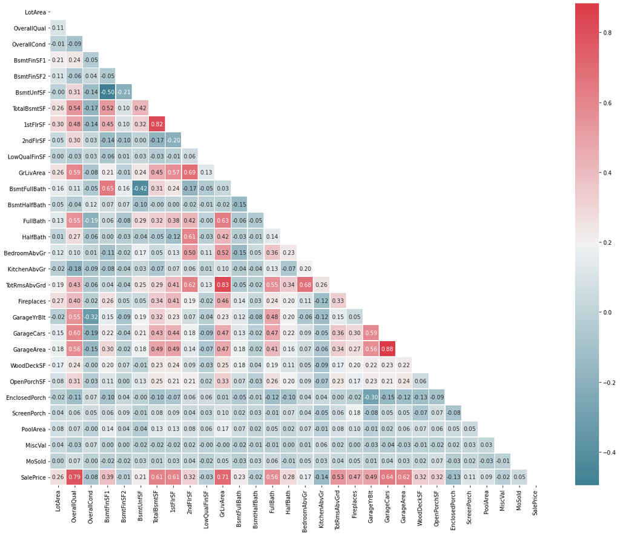

```python
# Running Seaborn heatmap for correlation on HT's quantitative variables
HT_Corr = HT.corr()

fig, ax = plt.subplots(figsize=(20, 16))
colormap = sns.diverging_palette(220, 10, as_cmap = True)
dropvals = np.zeros_like(HT_Corr)
dropvals[np.triu_indices_from(dropvals)] = True
sns.heatmap(HT_Corr, cmap = colormap, linewidths = .5, annot = True, fmt = ".2f", mask = dropvals)
plt.show()
```

```python
# Subsetting dependent SalePrice + eight independent variables from HT.
Sub_Pred = HT[["SalePrice","HalfBath","FullBath","BsmtFullBath","GarageCars","ExterQual","KitchenQual","PavedDrive","CentralAir"]]
```

**Question 2B**

```python
# Finding number of unique values in each column
print(Sub_Pred.nunique())
```

```
SalePrice       663
HalfBath          3
FullBath          4
BsmtFullBath      4
GarageCars        5
ExterQual         4
KitchenQual       4
PavedDrive        3
CentralAir        2
dtype: int64
```

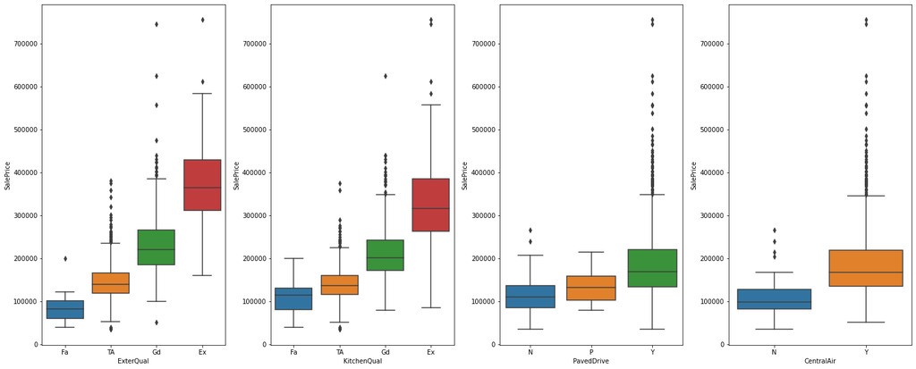

```python
# Box plots for SalePrice against GarageQual
fig, axes = plt.subplots(1, 4, figsize=(20,8), constrained_layout = True)
sns.boxplot(ax = axes[0], x = "ExterQual", y = "SalePrice", data = Sub_Pred,
            order = ["Fa", "TA", "Gd", "Ex"])
sns.boxplot(ax = axes[1], x = "KitchenQual", y = "SalePrice", data = Sub_Pred,
            order = ["Fa", "TA", "Gd", "Ex"])
sns.boxplot(ax = axes[2], x = "PavedDrive", y = "SalePrice", data = Sub_Pred,
            order = ["N","P","Y"])
sns.boxplot(ax = axes[3], x = "CentralAir", y = "SalePrice", data = Sub_Pred,
            order = ["N", "Y"])
```

**Question 2C**

```python
# Creating dummy variables for categorical variables
Sub_Pred_Dummy = pd.get_dummies(Sub_Pred, drop_first = True)
```

# Question 3 (Code)

**Question 3A**

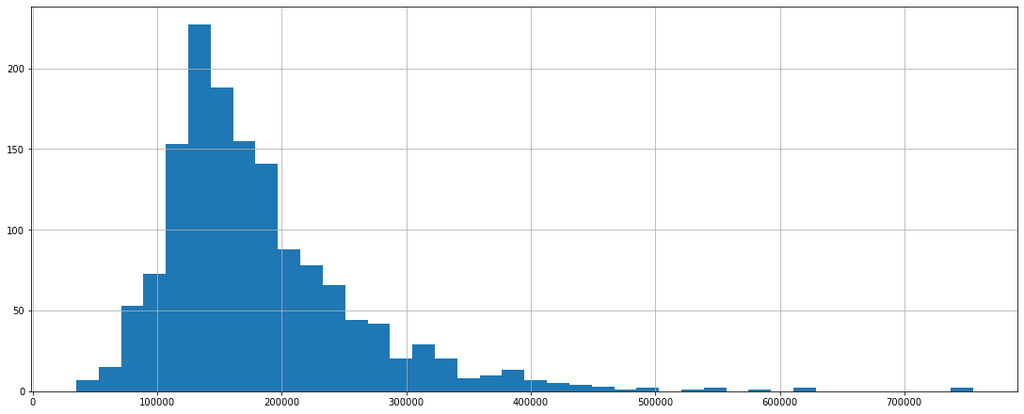

```python
# Plotting boxplot for SalePrice
SalePrice = Sub_Pred["SalePrice"]
fig, ax = plt.subplots(figsize=(15,6), constrained_layout = True)
plt.hist(SalePrice, bins = 40)
plt.grid()
```

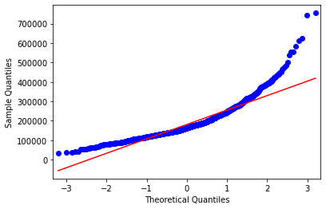

```python
# Plotting Q-Q plot for SalePrice
sm.qqplot(SalePrice, line = 'r');
```

**Question 3C**

```python
# Performing Box-Cox transformation on SalePrice to normalize distribution
stats.boxcox(SalePrice)
```

```
(array([7.93261046, 7.87826333, 7.95961804, ..., 8.02738182, 7.78100579,
        7.79588702]),
 -0.07692391328663316)
```

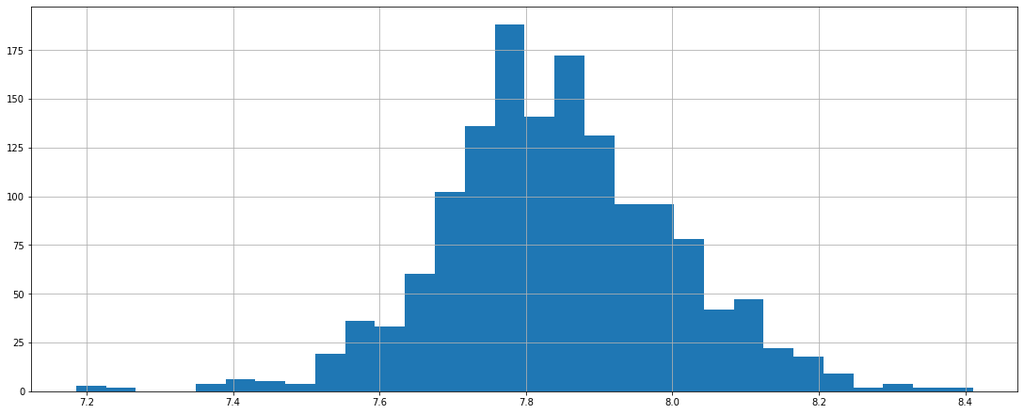

```python
SalePriceTransform = (((SalePrice + 1) ** -0.07692391328663316) - 1)/-0.07692391328663316

# Plotting boxplot for SalePriceTransform
fig, ax = plt.subplots(figsize=(15,6), constrained_layout = True)
plt.hist(SalePriceTransform, bins = 30)
plt.grid()
```

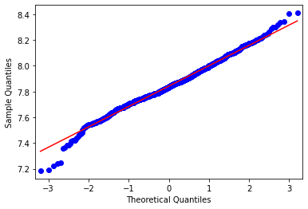

```python
# Plotting Q-Q plot for SalePriceTransform
sm.qqplot(SalePriceTransform, line = 'r');
```

# Question 4 (Code)

**Question 4A**

```python
# Taking copy of Sub_Pred and overwriting SalePrice column with log(SalePrice)
Sub_Pred_Log = Sub_Pred_Dummy.copy()
Sub_Pred_Log["SalePrice"] = np.log(SalePrice)
Sub_Pred_Log
```

|  | SalePrice | HalfBath | FullBath | BsmtFullBath | GarageCars | ExterQual_Fa | ExterQual_Gd | ExterQual_TA | KitchenQual_Fa | KitchenQual_Gd | KitchenQual_TA | PavedDrive_P | PavedDrive_Y | CentralAir_Y |
| --- | --- | --- | --- | --- | --- | --- | --- | --- | --- | --- | --- | --- | --- | --- |
| 0 | 12.247694 | 1 | 2 | 1 | 2 | 0 | 1 | 0 | 0 | 1 | 0 | 0 | 1 | 1 |
| 1 | 12.109011 | 0 | 2 | 0 | 2 | 0 | 0 | 1 | 0 | 0 | 1 | 0 | 1 | 1 |
| 2 | 12.317167 | 1 | 2 | 1 | 2 | 0 | 1 | 0 | 0 | 1 | 0 | 0 | 1 | 1 |
| 3 | 11.849398 | 0 | 1 | 1 | 3 | 0 | 0 | 1 | 0 | 1 | 0 | 0 | 1 | 1 |
| 4 | 12.429216 | 1 | 2 | 1 | 3 | 0 | 1 | 0 | 0 | 1 | 0 | 0 | 1 | 1 |
| ... | ... | ... | ... | ... | ... | ... | ... | ... | ... | ... | ... | ... | ... | ... |
| 1455 | 12.072541 | 1 | 2 | 0 | 2 | 0 | 0 | 1 | 0 | 0 | 1 | 0 | 1 | 1 |
| 1456 | 12.254863 | 0 | 2 | 1 | 2 | 0 | 0 | 1 | 0 | 0 | 1 | 0 | 1 | 1 |
| 1457 | 12.493130 | 0 | 2 | 0 | 1 | 0 | 0 | 0 | 0 | 1 | 0 | 0 | 1 | 1 |
| 1458 | 11.864462 | 0 | 1 | 1 | 1 | 0 | 0 | 1 | 0 | 1 | 0 | 0 | 1 | 1 |
| 1459 | 11.901583 | 1 | 1 | 1 | 1 | 0 | 1 | 0 | 0 | 0 | 1 | 0 | 1 | 1 |

1460 rows × 14 columns

```python
Sub_Pred_Model = smf.ols(formula = 'SalePrice ~ HalfBath + FullBath + BsmtFullBath + GarageCars + ExterQual_Fa + ExterQual_Gd + ExterQual_TA + KitchenQual_Fa + KitchenQual_Gd + KitchenQual_TA + PavedDrive_P + PavedDrive_Y + CentralAir_Y', data = Sub_Pred_Log)
Sub_Pred_ModelFit = Sub_Pred_Model.fit()
print(Sub_Pred_ModelFit.summary())
```

```
                            OLS Regression Results
==============================================================================
Dep. Variable:              SalePrice   R-squared:                       0.738
Model:                            OLS   Adj. R-squared:                  0.735
Method:                 Least Squares   F-statistic:                     312.8
Date:                Tue, 02 Nov 2021   Prob (F-statistic):               0.00
Time:                        18:13:22   Log-Likelihood:                 245.45
No. Observations:                1460   AIC:                            -462.9
Df Residuals:                    1446   BIC:                            -388.9
Df Model:                          13
Covariance Type:            nonrobust
==================================================================================
                     coef    std err          t      P>|t|      [0.025      0.975]
----------------------------------------------------------------------------------
Intercept         11.5617      0.050    229.920      0.000      11.463      11.660
HalfBath           0.1035      0.011      9.328      0.000       0.082       0.125
FullBath           0.1992      0.012     16.544      0.000       0.176       0.223
BsmtFullBath       0.1134      0.011     10.513      0.000       0.092       0.135
GarageCars         0.1448      0.009     15.511      0.000       0.126       0.163
ExterQual_Fa      -0.4407      0.071     -6.195      0.000      -0.580      -0.301
ExterQual_Gd      -0.1657      0.036     -4.663      0.000      -0.235      -0.096
ExterQual_TA      -0.2851      0.038     -7.474      0.000      -0.360      -0.210
KitchenQual_Fa    -0.2987      0.047     -6.353      0.000      -0.391      -0.206
KitchenQual_Gd    -0.2070      0.027     -7.778      0.000      -0.259      -0.155
KitchenQual_TA    -0.3026      0.029    -10.287      0.000      -0.360      -0.245
PavedDrive_P       0.1097      0.044      2.502      0.012       0.024       0.196
PavedDrive_Y       0.0857      0.025      3.482      0.001       0.037       0.134
CentralAir_Y       0.2203      0.024      9.016      0.000       0.172       0.268
==============================================================================
Omnibus:                       62.345   Durbin-Watson:                   2.011
Prob(Omnibus):                  0.000   Jarque-Bera (JB):              148.667
Skew:                          -0.220   Prob(JB):                     5.22e-33
Kurtosis:                       4.500   Cond. No.                         50.6
==============================================================================

Notes:
[1] Standard Errors assume that the covariance matrix of the errors is correctly specified.
```

**Question 4B**

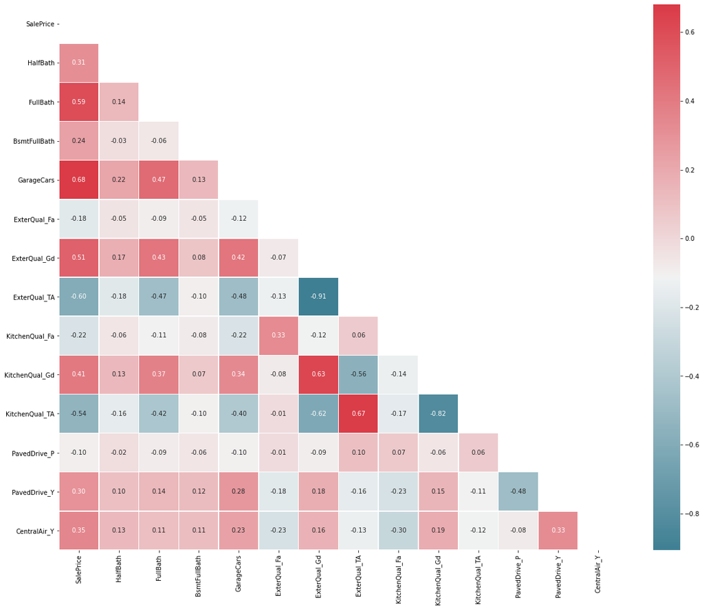

```python
# Running Seaborn heatmap for correlation on Sub_Pred_Log's quantitative variables
Sub_Pred_Log_Corr = Sub_Pred_Log.corr()

fig, ax = plt.subplots(figsize=(20, 16))
colormap = sns.diverging_palette(220, 10, as_cmap = True)
dropvals = np.zeros_like(Sub_Pred_Log_Corr)
dropvals[np.triu_indices_from(dropvals)] = True
sns.heatmap(Sub_Pred_Log_Corr, cmap = colormap, linewidths = .5, annot = True, fmt = ".2f", mask = dropvals)
plt.show()
```

[figure not shown]

```python
# Checking scatter of log(SalePrice) against GarageCars to check for
# decreasing/increasing marginal effects
plt.figure(figsize=(10,8))
plt.title("log(SalePrice) Against GarageCars")
plt.ylabel("log(SalePrice)")
plt.xlabel("GarageCars")
plt.scatter(Sub_Pred_Log["GarageCars"], SalePrice)
plt.grid()
```

```python
# Declaring the higher order terms of GarageCars
GarageCars = Sub_Pred_Log["GarageCars"]
Sub_Pred_Log["GarageCarsSqr"] = GarageCars ** 2
```

```python
# Declaring interaction terms for KitchenQual and ExterQual
Sub_Pred_Log["KitchenExterQual_Fa"] = Sub_Pred_Log["KitchenQual_Fa"] * Sub_Pred_Log["ExterQual_Fa"]
Sub_Pred_Log["KitchenExterQual_TA"] = Sub_Pred_Log["KitchenQual_TA"] * Sub_Pred_Log["ExterQual_TA"]
Sub_Pred_Log["KitchenExterQual_Gd"] = Sub_Pred_Log["KitchenQual_Gd"] * Sub_Pred_Log["ExterQual_Gd"]
```

```python
Sub_Pred_Model = smf.ols(formula = 'SalePrice ~ HalfBath + FullBath + BsmtFullBath + GarageCars + GarageCarsSqr + ExterQual_Fa + ExterQual_Gd + ExterQual_TA + KitchenQual_Fa + KitchenQual_Gd + KitchenQual_TA + PavedDrive_P + PavedDrive_Y + CentralAir_Y + KitchenExterQual_Fa + KitchenExterQual_TA + KitchenExterQual_Gd', data = Sub_Pred_Log)
Sub_Pred_ModelFit = Sub_Pred_Model.fit()
print(Sub_Pred_ModelFit.summary())
```

```
                            OLS Regression Results
==============================================================================
Dep. Variable:              SalePrice   R-squared:                       0.742
Model:                            OLS   Adj. R-squared:                  0.738
Method:                 Least Squares   F-statistic:                     243.4
Date:                Tue, 02 Nov 2021   Prob (F-statistic):               0.00
Time:                        18:23:39   Log-Likelihood:                 256.35
No. Observations:                1460   AIC:                            -476.7
Df Residuals:                    1442   BIC:                            -381.6
Df Model:                          17
Covariance Type:            nonrobust
=======================================================================================
                          coef    std err          t      P>|t|      [0.025      0.975]
---------------------------------------------------------------------------------------
Intercept              11.5540      0.050    229.447      0.000      11.455      11.653
HalfBath                0.1030      0.011      9.319      0.000       0.081       0.125
FullBath                0.1977      0.012     16.487      0.000       0.174       0.221
BsmtFullBath            0.1124      0.011     10.477      0.000       0.091       0.133
GarageCars              0.0764      0.025      3.052      0.002       0.027       0.125
GarageCarsSqr           0.0205      0.007      2.853      0.004       0.006       0.035
ExterQual_Fa           -0.3266      0.099     -3.293      0.001      -0.521      -0.132
ExterQual_Gd           -0.0849      0.041     -2.079      0.038      -0.165      -0.005
ExterQual_TA           -0.3970      0.052     -7.630      0.000      -0.499      -0.295
KitchenQual_Fa         -0.1463      0.062     -2.348      0.019      -0.268      -0.024
KitchenQual_Gd         -0.0449      0.050     -0.905      0.365      -0.142       0.052
KitchenQual_TA         -0.3447      0.046     -7.550      0.000      -0.434      -0.255
PavedDrive_P            0.1171      0.044      2.672      0.008       0.031       0.203
PavedDrive_Y            0.0946      0.025      3.809      0.000       0.046       0.143
CentralAir_Y            0.2300      0.024      9.413      0.000       0.182       0.278
KitchenExterQual_Fa    -0.2753      0.135     -2.045      0.041      -0.539      -0.011
KitchenExterQual_TA     0.1939      0.066      2.917      0.004       0.064       0.324
KitchenExterQual_Gd    -0.2092      0.058     -3.593      0.000      -0.323      -0.095
==============================================================================
Omnibus:                       65.122   Durbin-Watson:                   2.009
Prob(Omnibus):                  0.000   Jarque-Bera (JB):              158.472
Skew:                          -0.228   Prob(JB):                     3.87e-35
Kurtosis:                       4.548   Cond. No.                         169.
==============================================================================

Notes:
[1] Standard Errors assume that the covariance matrix of the errors is correctly specified.
```

Note: Not sure why KitchenExterQual_TA provides a positive coef. Check further before submitting.

**Question 4C**

[figure not shown]

```python
plt.figure(figsize=(10,8))
plt.title("Residuals of MR on log(SalePrice)")
plt.ylabel("log(SalePrice)")
plt.xlabel("GarageCars")
plt.hist(Sub_Pred_ModelFit.resid, bins = 30)
plt.grid()
```

```python
stats.jarque_bera(Sub_Pred_ModelFit.resid)
```

```
Jarque_beraResult(statistic=158.47192858630405, pvalue=0.0)
```